# JHU Data Science - Machine Learning Project

MrCheerful

March 20, 2017

## Project Assignment

The assignment is described on the [Coursera Website](https://www.coursera.org/learn/practical-machine-learning/supplement/PvInj/course-project-instructions-read-first). So I won’t waste your screen space repeating it.

In short, build a prediction model, and evaluate a graded test set.

### Project Environment

Packages loaded: ggplot2, caret, dplyr, reshape2, doParallel, randomForest

### Project Data

Links to the filesets are provided on the Coursera page provided above.

Details of the data, in particular, the chart showing where the sensors are placed, may be found at [the webpage for the data](http://groupware.les.inf.puc-rio.br/har)

```r
link1 <- "https://d396qusza40orc.cloudfront.net/predmachlearn/pml-training.csv"
file1 <- "pml-training.csv"
link2 <- "https://d396qusza40orc.cloudfront.net/predmachlearn/pml-testing.csv"
file2 <- "pml-testing.csv"
if (!file.exists(file1)){ download.file(link1, destfile = file1, method="curl") }
if (!file.exists(file2)){ download.file(link2, destfile = file2, method="curl") }
```

### Load and Clean Data

Data is loaded with default conversion to factors.

```r
train <- read.csv("pml-training.csv")
test <- read.csv("pml-testing.csv")
```

The pml-training file contains a large number of columns that are only used with rows where new_window=yes. From the data exploration it was determined that these columns are not useful for the predictions required, so they are removed.

- cols.yes - data columns applicable to rows with new_window=yes
- cols.no - data columns applicable to rows with new_window=yes
- cols.e.yes - data columns exclusively used only with new_window=yes

```r
cols.yes <- names(train)[-c(1:7,160)]
cols.no <- names(train)[-c(1:7,12:36,50:59,69:83,87:101,103:112,125:139,141:150,160)]
cols.e.yes <- cols.yes[!(cols.yes %in% cols.no)]
trs <- train[,!(names(train) %in% cols.e.yes)]
```

### Data Partition

The data is split 60:40 into a training and an evaluation set

```r
set.seed(54321)
inTrain <- createDataPartition(y=trs$X, p=0.6, list=FALSE)
trs.train <- trs[inTrain,]
trs.test <- trs[-inTrain,]
dim(trs.train) ; dim(trs.test)
```

```
## [1] 11774    60
```

```
## [1] 7848   60
```

## Data Exploration Highlights

An in depth examination of the data was conducted to understand how the dataset was made up and the relationships with the exercise activity to be evaluated. Highlights of the examination are discussed.

#### Motion vs Snapshot

The data presents sequences of measurements as the subject is performing an activity. In the chart below a movement sequence is plotted for an example motion. Some of the sensors are near constant for a sequence, and others show the changing movement. For the purposes of this assignment, the objective is to predict if the activity is being preformed correctly based on a snapshot at one point in time along the sequence.

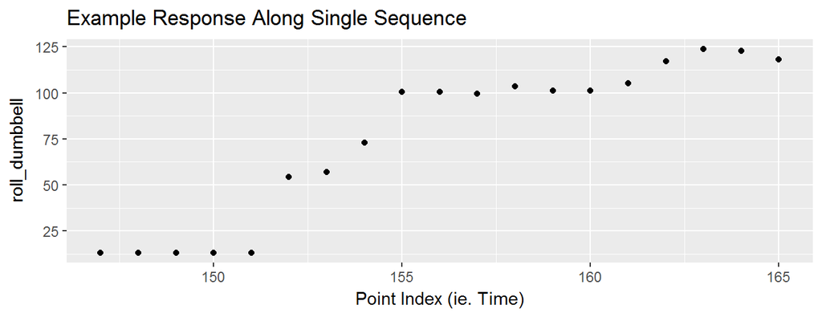

```r
sequ <- subset(trs, num_window== 18)
gs <- ggplot(data=sequ, aes(x=X, y=roll_dumbbell)) + geom_point() +
      labs(title="Example Response Along Single Sequence", x="Point Index (ie. Time)"); gs
```

#### Subtle Variations

The differences between a correct movement and an incorrect movement are subtle. The violin plot shows the range of an example sensor between the correctly executed movement (A) and the four incorrectly executed movements (B through E). The point plot below illustrates the relationship between two example sensors and the overlapping of the clusters between the different classes of movements.

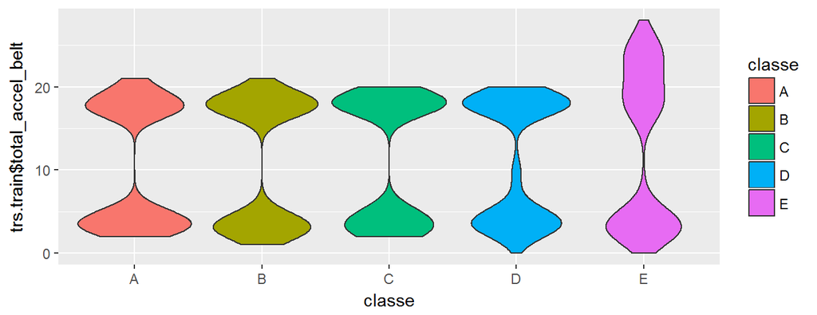

```r
gv <- ggplot(data=trs.train, aes_string(x="classe", y=paste("trs.train",cols.no[4],sep="$"), fill="classe")) + geom_violin() ; gv
```

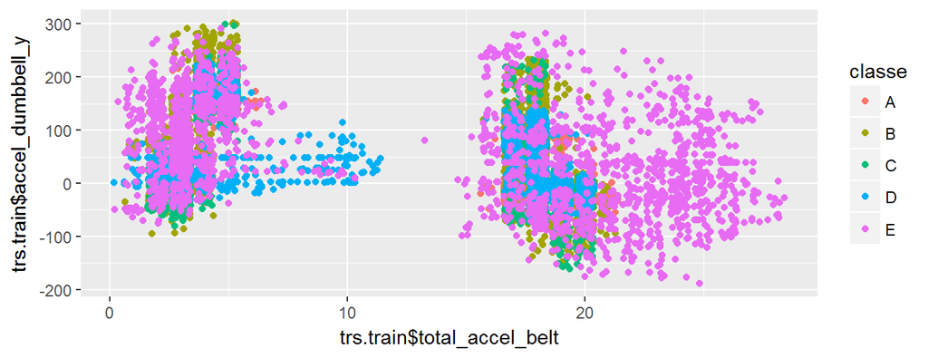

```r
gc <- ggplot(data=trs.train, aes_string(x=paste("trs.train",cols.no[4],sep="$"), y=paste("trs.train",cols.no[35],sep="$"), color="classe")) + geom_point(position="jitter") ; gc
```

## Prediction Model

Several possible models were examined. The glm model did not work because the GLM algorithm only accepts 2-class outcomes, not a 5 class outcome as is required here. A decision tree resulted in less than 50% accuracy, which is not sufficient to pass the quiz.

#### Random Forest Model

A random forest (method=“rf”) model is found to give an in-sample accuracy of 100%, and an out-of-sample accuracy over 99% which is more than sufficient to pass the quiz.

For this model the parameters are set to cross-validate with 5 folds.

```r
# set up a formula for classe ~ <all predictor columns> and rf parameters
form.all <- as.formula(paste("classe~", paste(cols.no, collapse= "+") ))
parms <- trainControl(method="cv", number=5)

# set up for a parallel processing environment and run training operation
clust <- makeCluster(detectCores())
registerDoParallel(clust)
fit.rpart <- train(form=form.all, data=trs.train, method="rf",
                   allowParallel = TRUE, trControl = parms)
stopCluster(clust)
```

### Output

##### Predictions on training group & confusion matrix

```r
trs.train.pr <- predict(fit.rpart)
confusionMatrix(trs.train.pr, trs.train$classe)
```

```
## Confusion Matrix and Statistics
##
##           Reference
## Prediction    A    B    C    D    E
##          A 3346    0    0    0    0
##          B    0 2265    0    0    0
##          C    0    0 2068    0    0
##          D    0    0    0 1932    0
##          E    0    0    0    0 2163
##
## Overall Statistics
##
##                Accuracy : 1
##                  95% CI : (0.9997, 1)
##     No Information Rate : 0.2842
##     P-Value [Acc > NIR] : < 2.2e-16
##
##                   Kappa : 1
##  Mcnemar's Test P-Value : NA
##
## Statistics by Class:
##
##                      Class: A Class: B Class: C Class: D Class: E
## Sensitivity            1.0000   1.0000   1.0000   1.0000   1.0000
## Specificity            1.0000   1.0000   1.0000   1.0000   1.0000
## Pos Pred Value         1.0000   1.0000   1.0000   1.0000   1.0000
## Neg Pred Value         1.0000   1.0000   1.0000   1.0000   1.0000
## Prevalence             0.2842   0.1924   0.1756   0.1641   0.1837
## Detection Rate         0.2842   0.1924   0.1756   0.1641   0.1837
## Detection Prevalence   0.2842   0.1924   0.1756   0.1641   0.1837
## Balanced Accuracy      1.0000   1.0000   1.0000   1.0000   1.0000
```

##### Predictions on test group

```r
trs.test.pr <- predict(fit.rpart, newdata = trs.test)
confusionMatrix(trs.test.pr, trs.test$classe)
```

```
## Confusion Matrix and Statistics
##
##           Reference
## Prediction    A    B    C    D    E
##          A 2230   10    0    0    0
##          B    2 1518    9    0    1
##          C    1    4 1338   17    2
##          D    0    0    5 1265   10
##          E    1    0    2    2 1431
##
## Overall Statistics
##
##                Accuracy : 0.9916
##                  95% CI : (0.9893, 0.9935)
##     No Information Rate : 0.2847
##     P-Value [Acc > NIR] : < 2.2e-16
##
##                   Kappa : 0.9894
##  Mcnemar's Test P-Value : NA
##
## Statistics by Class:
##
##                      Class: A Class: B Class: C Class: D Class: E
## Sensitivity            0.9982   0.9909   0.9882   0.9852   0.9910
## Specificity            0.9982   0.9981   0.9963   0.9977   0.9992
## Pos Pred Value         0.9955   0.9922   0.9824   0.9883   0.9965
## Neg Pred Value         0.9993   0.9978   0.9975   0.9971   0.9980
## Prevalence             0.2847   0.1952   0.1725   0.1636   0.1840
## Detection Rate         0.2841   0.1934   0.1705   0.1612   0.1823
## Detection Prevalence   0.2854   0.1950   0.1735   0.1631   0.1830
## Balanced Accuracy      0.9982   0.9945   0.9922   0.9915   0.9951
```

##### Predictions for quiz submission

```r
test.rpart.pr <- predict(fit.rpart, newdata=test)
test.rpart.pr
```

```
##  [1] B A B A A E D B A A B C B A E E A B B B
## Levels: A B C D E
```

Looks awesome!